# Network motifs in communities

Chang-Yu Chang

2019-11-13

# Goal

- Make community network from `data/output/pairs.csv`.
- Plot networks and matrices

For `R >= 3.5.0`, use `BiocManager::install()` instead of `biocLite()` to install Bioconductor-mentained packages.

```r
#install.packages("PlayerRatings") # Calculate the rank
install.packages("igraph") # Network analysis
```

```r
library(igraph)
library(tidygraph)
library(ggraph)
```

# Make network

Plot network

Network in circle

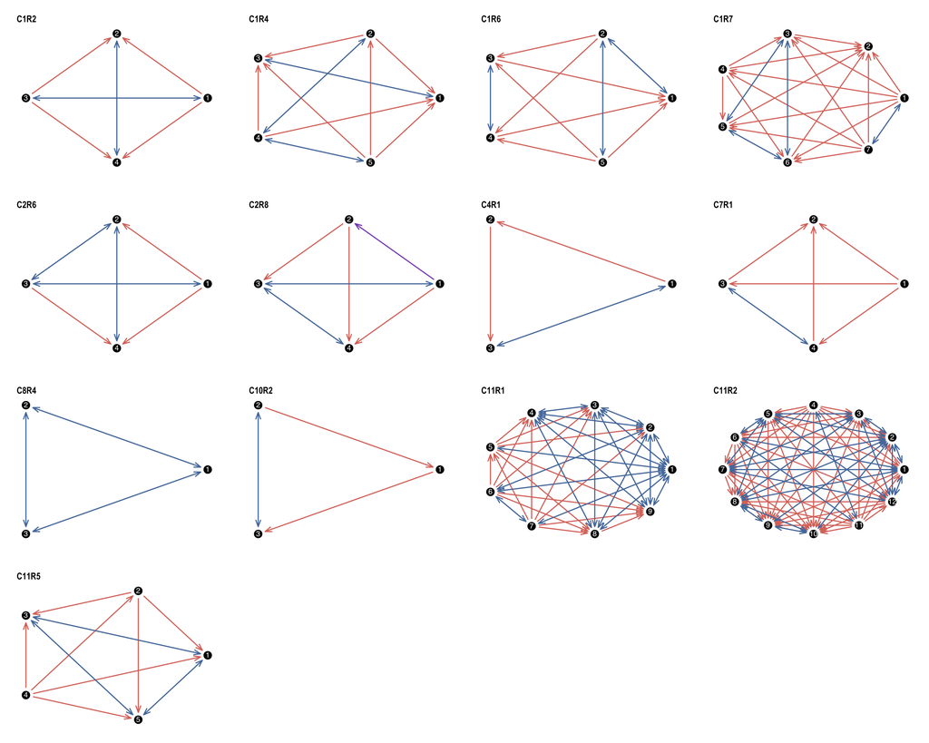

# Pairwise matrice

Tournament ranks of each isolate. Note that I consider neturality and bistability as draw in the tournament.

- `Score`: the competitive scores of isolate. This score is computed by the formula: number of wins - number of loses + 0 * number of draws.
- `Game`: number of pairwise competition the isolate has played. The number of games an isolate plated within a community should be community size minus one.
- `Rank`: the ranks based on `Score`. The ranks range from 1 to the focal community size. Isolates with the same scores in a community are given the same rank.
- `PlotRank`: continuous rank for plotting convenience.

| Community | Isolate | Win | Lose | Draw | Score | Game | Rank | PlotRank |
| --- | --- | --- | --- | --- | --- | --- | --- | --- |
| C1R2 | 1 | 2 | 0 | 1 | 2 | 3 | 1 | 1 |
| C1R2 | 2 | 0 | 2 | 1 | -2 | 3 | 3 | 3 |
| C1R2 | 3 | 2 | 0 | 1 | 2 | 3 | 1 | 2 |
| C1R2 | 4 | 0 | 2 | 1 | -2 | 3 | 3 | 4 |
| C1R4 | 1 | 0 | 3 | 1 | -3 | 4 | 4 | 4 |
| C1R4 | 2 | 2 | 1 | 1 | 1 | 4 | 3 | 3 |
| C1R4 | 3 | 0 | 3 | 1 | -3 | 4 | 4 | 5 |
| C1R4 | 4 | 2 | 0 | 2 | 2 | 4 | 2 | 2 |
| C1R4 | 5 | 3 | 0 | 1 | 3 | 4 | 1 | 1 |
| C1R6 | 1 | 0 | 3 | 1 | -3 | 4 | 5 | 5 |

[output cut: 58 more lines]

# Randomize networks

The R list for randomzied networks are saved within the R script. For record, it took 2603 seconds ~= 40 mins to generate 10000 randomized networks for each of 13 communities.

The randomized networks are saved in `data/temp/network_random_list.Rdata` which contains a two-layer R list `net_random_list` in which the first layer has the 13 communities and the second layer has 10000 randomized networks.

Example of randomized network matrix

[figure not shown]